# ARIMAX/SARIMAX Model for Dow Jones index and macroeconomic factors

Endogenous variable: Dow Jones Index Exogenous variables: Macroeconomic indicators such as GDP, inflation rate, unemployment rate and interest rates

Before proceeding with model selection, it can be useful to examine the feature variables and select the appropriate ones. This can be done by creating cross-correlation function plots, which can serve as a verification of the correlation heatmap for the variables.

##### CCF Plot for Dow Jones and Exogenous Variables

**GDP**

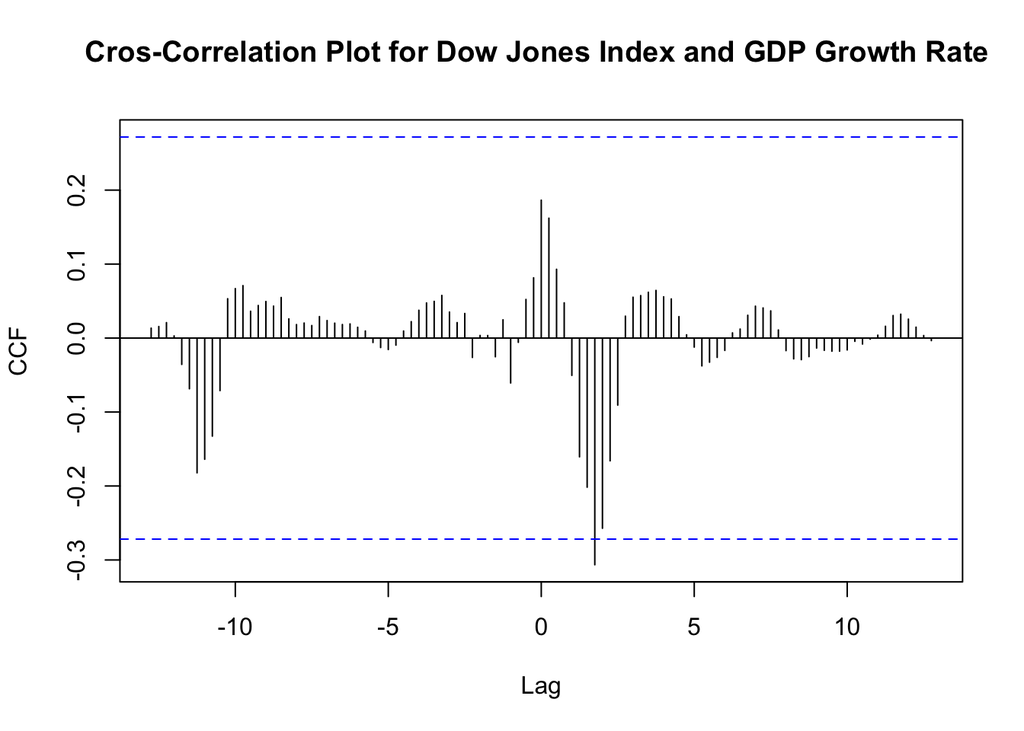

```r
par(mfrow=c(1,1))
ccf_result <- ccf(normalized_index_factor_data[, c("DJI.Adjusted")], normalized_index_factor_data[, c("gdp")],
    lag.max = 300,
    main = "Cros-Correlation Plot for Dow Jones Index and GDP Growth Rate ",
    ylab = "CCF")
```

```r
cat("The sum of cross correlation function is", sum(abs(ccf_result$acf)))
```

```
The sum of cross correlation function is 4.745225
```

**Interest Rate**

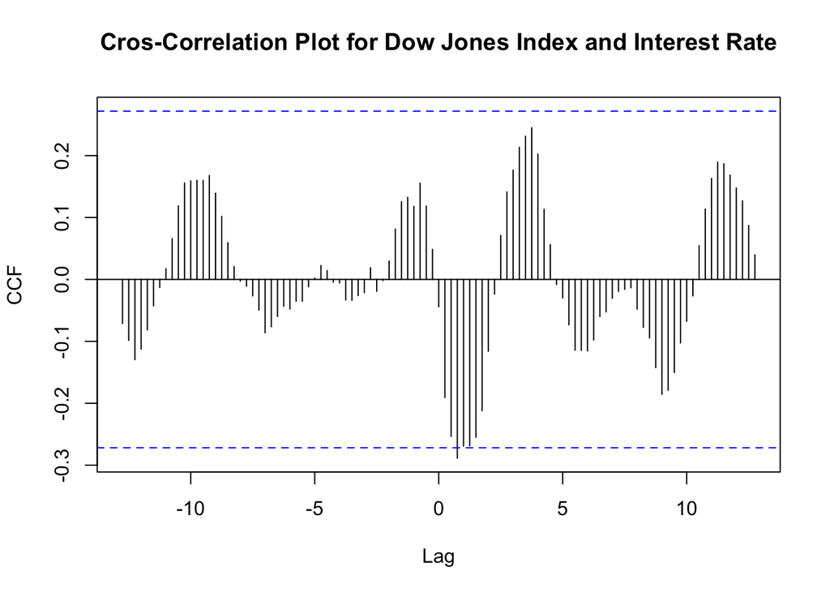

```r
par(mfrow=c(1,1))
ccf_result <- ccf(normalized_index_factor_data[, c("DJI.Adjusted")], normalized_index_factor_data[, c("interest")],
    lag.max = 300,
    main = "Cros-Correlation Plot for Dow Jones Index and Interest Rate",
    ylab = "CCF")
```

```r
cat("The sum of cross correlation function is", sum(abs(ccf_result$acf)))
```

```
The sum of cross correlation function is 9.845121
```

**Inflation Rate**

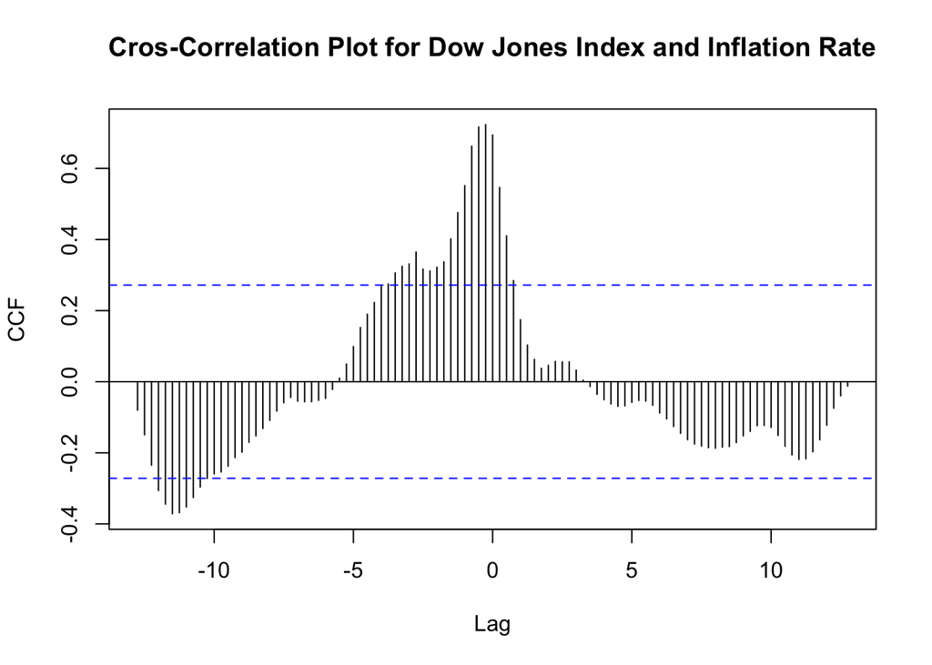

```r
par(mfrow=c(1,1))
ccf_result <- ccf(normalized_index_factor_data[, c("DJI.Adjusted")], normalized_index_factor_data[, c("inflation")],
    lag.max = 300,
    main = "Cros-Correlation Plot for Dow Jones Index and Inflation Rate",
    ylab = "CCF")
```

```r
cat("The sum of cross correlation function is", sum(abs(ccf_result$acf)))
```

```
The sum of cross correlation function is 19.95814
```

**Unemployment Rate**

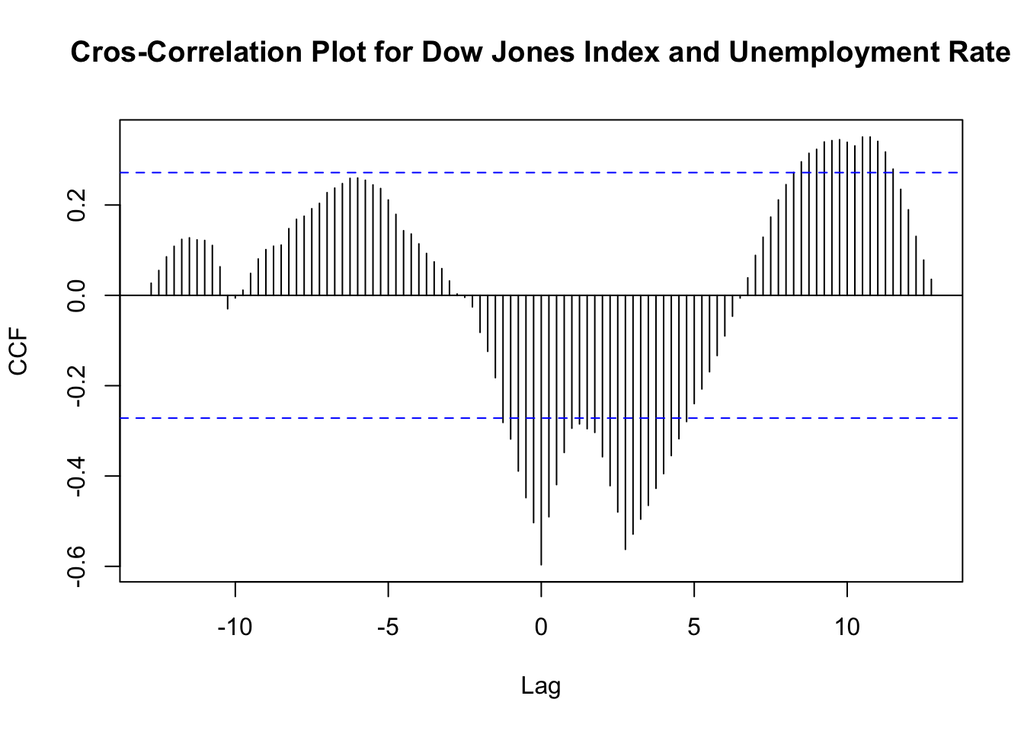

```r
par(mfrow=c(1,1))
ccf_result <- ccf(normalized_index_factor_data[, c("DJI.Adjusted")], normalized_index_factor_data[, c("unemployment")],
    lag.max = 300,
    main = "Cros-Correlation Plot for Dow Jones Index and Unemployment Rate",
    ylab = "CCF")
```

```r
cat("The sum of cross correlation function is", sum(abs(ccf_result$acf)))
```

```
The sum of cross correlation function is 22.80055
```

The cross-correlation feature plots reaffirm the findings from the heatmap analysis, indicating that inflation and unemployment rate exhibit stronger correlations with the index compared to GDP and interest rates. The cross-correlation plots for GDP and interest rates show weaker and more scattered patterns, with strikes between the blue lines indicating lower correlation coefficients. This suggests that inflation and unemployment rate are more suitable feature variables for the ARIMAXmodel when predicting Dow Jones movements.

Final Exogenous variables: Macroeconomic indicators: Inflation rate and unemployment rate.

##### Endogenous and Exogenous Variables Plot

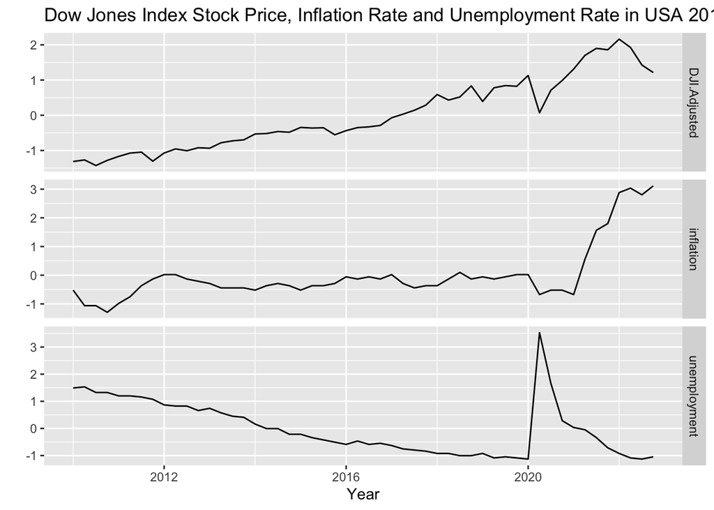

```r
final_dj_factor_data <- index_factor_data %>%dplyr::select( Date,DJI.Adjusted, inflation,unemployment)
numeric_vars_dj_factor_data <- c("DJI.Adjusted", "inflation", "unemployment")
numeric_dj_factor_data <- final_dj_factor_data[, numeric_vars_dj_factor_data]
normalized_dj_factor_data_numeric <- scale(numeric_dj_factor_data)
normalized_dj_factor_data_numeric_df <- data.frame(normalized_dj_factor_data_numeric)
normalized_dj_factor_data_ts <- ts(normalized_dj_factor_data_numeric, start = c(2010, 1), frequency = 4)

autoplot(normalized_dj_factor_data_ts, facets=TRUE) +
  xlab("Year") + ylab("") +
  ggtitle("Dow Jones Index Stock Price, Inflation Rate and Unemployment Rate in USA 2010-2023")
```

##### Check the stationarity

Before proceeding with further analysis, it’s important to check the stationarity of the time series data. If the series is not stationary, it needs to be differentiated before performing ARIMAX model. The stationarity of a multivariate time series data can be checked using the Phillips-Perron test, which is specifically designed for multivariate data. By performing the Phillips-Perron test on the multivariate time series data, we can determine if the data is stationary or if it requires differencing to make it suitable for ARIMAX modeling.

```r
# Convert your multivariate time series data to a matrix
final_dj_factor_data_ts_multivariate <- as.matrix(normalized_dj_factor_data_ts)

# Check for stationarity using Phillips-Perron test
phillips_perron_test <- ur.pp(final_dj_factor_data_ts_multivariate)
summary(phillips_perron_test)
```

```
##################################
# Phillips-Perron Unit Root Test #
##################################

Test regression with intercept


Call:
lm(formula = y ~ y.l1)

Residuals:
    Min      1Q  Median      3Q     Max
-1.5621 -0.1561 -0.0549  0.0940  4.4921

Coefficients:
            Estimate Std. Error t value Pr(>|t|)
(Intercept) 0.002691   0.040890   0.066    0.948
y.l1        0.857196   0.041305  20.753   <2e-16 ***
---
Signif. codes:  0 '***' 0.001 '**' 0.01 '*' 0.05 '.' 0.1 ' ' 1

Residual standard error: 0.5091 on 153 degrees of freedom
Multiple R-squared:  0.7379,    Adjusted R-squared:  0.7362
F-statistic: 430.7 on 1 and 153 DF,  p-value: < 2.2e-16


Value of test-statistic, type: Z-alpha  is: -22.979

         aux. Z statistics
Z-tau-mu            0.0656
```

The Phillips-Perron unit root test output suggests that the data is stationary. The test regression includes an intercept term and tests whether the coefficient on the lagged value is significantly different from one. The estimated coefficients indicate that the intercept is not significant (p-value > 0.05), while the coefficient on the lagged value is highly significant (p-value < 2.2e-16), suggesting that the data is stationary.

Additionally, the “Z-alpha” value is the test statistic, which is compared to critical values of the standard normal distribution to determine significance. In this case, the test statistic is -22.979, indicating strong evidence against the null hypothesis of a unit root. The “Z-tau-mu” value is an auxiliary test statistic used to correct for autocorrelation in the residuals, and it is close to zero, suggesting that there is no evidence of residual autocorrelation.

##### Fitting a ARIMAX model

Fitting an ARIMAX model will be a useful approach to modeling and predicting time series data when external factors are believed to have an impact on the response variable. In this case, we will be using an ARIMAX model to predict the DJI Index, taking into account the effects of inflation and unemployment on the Index. By including these exogenous variables in our model, we can improve the accuracy of our predictions and gain a better understanding of the underlying dynamics of the time series.

**Auto ARIMA**

```r
xreg <- cbind(Inflation = normalized_dj_factor_data_ts[, "inflation"],
              Unemployment = normalized_dj_factor_data_ts[, "unemployment"])

fit <- auto.arima(normalized_dj_factor_data_ts[, "DJI.Adjusted"], xreg = xreg)
summary(fit)
```

```
Series: normalized_dj_factor_data_ts[, "DJI.Adjusted"]
Regression with ARIMA(0,1,0) errors

Coefficients:
      Inflation  Unemployment
         0.0999       -0.2337
s.e.     0.0804        0.0365

sigma^2 = 0.03424:  log likelihood = 14.7
AIC=-23.4   AICc=-22.89   BIC=-17.6

Training set error measures:
                     ME      RMSE       MAE      MPE     MAPE      MASE
Training set 0.03018628 0.1796281 0.1389231 4.691153 32.83951 0.3988319
                    ACF1
Training set -0.07188426
```

**Residuals**

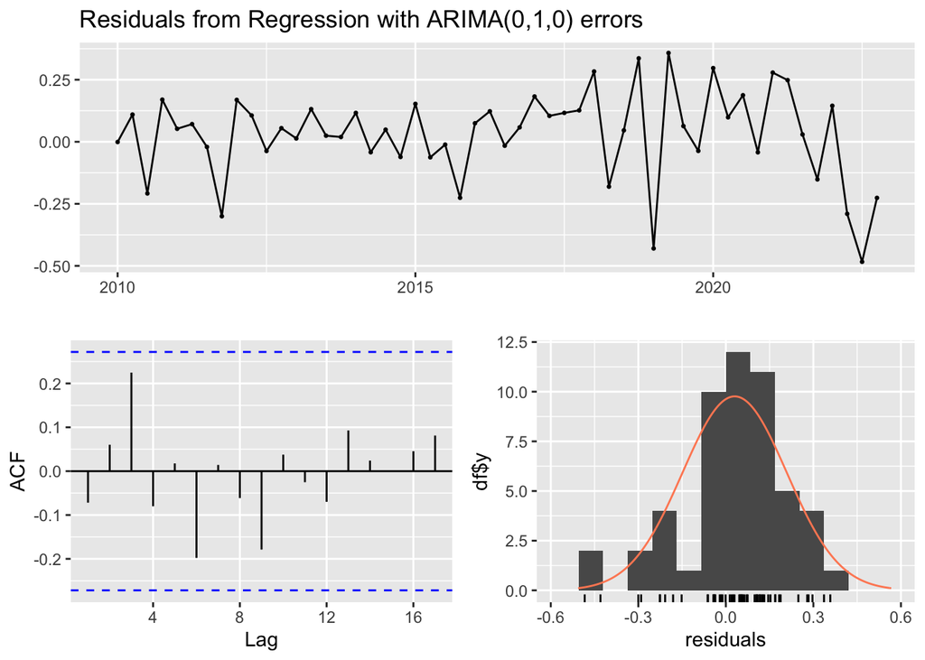

```
    Ljung-Box test

data:  Residuals from Regression with ARIMA(0,1,0) errors
Q* = 6.4181, df = 8, p-value = 0.6005

Model df: 0.   Total lags used: 8
```

```r
checkresiduals(fit)
```

##### Fitting the model manually

**Linear Model**

```r
normalized_dj_factor_data_numeric_df$DJI.Adjusted<-ts(normalized_dj_factor_data_numeric_df$DJI.Adjusted,star=decimal_date(as.Date("2010-01-01",format = "%Y-%m-%d")),frequency = 4)
normalized_dj_factor_data_numeric_df$inflation<-ts(normalized_dj_factor_data_numeric_df$inflation,star=decimal_date(as.Date("2010-01-01",format = "%Y-%m-%d")),frequency = 4)
normalized_dj_factor_data_numeric_df$unemployment<-ts(normalized_dj_factor_data_numeric_df$unemployment,star=decimal_date(as.Date("2010-01-01",format = "%Y-%m-%d")),frequency = 4)

############# First fit the linear model##########
fit.reg <- lm(DJI.Adjusted ~ inflation+unemployment, data=normalized_dj_factor_data_numeric_df)
summary(fit.reg)
```

```
Call:
lm(formula = DJI.Adjusted ~ inflation + unemployment, data = normalized_dj_factor_data_numeric_df)

Residuals:
    Min      1Q  Median      3Q     Max
-0.8660 -0.4391 -0.2518  0.3505  1.6797

Coefficients:
               Estimate Std. Error t value Pr(>|t|)
(Intercept)   1.180e-16  9.263e-02   0.000   1.0000
inflation     5.296e-01  1.067e-01   4.963 8.79e-06 ***
unemployment -3.416e-01  1.067e-01  -3.202   0.0024 **
---
Signif. codes:  0 '***' 0.001 '**' 0.01 '*' 0.05 '.' 0.1 ' ' 1

Residual standard error: 0.668 on 49 degrees of freedom
Multiple R-squared:  0.5713,    Adjusted R-squared:  0.5538
F-statistic: 32.65 on 2 and 49 DF,  p-value: 9.73e-10
```

**ACF of Residuals**

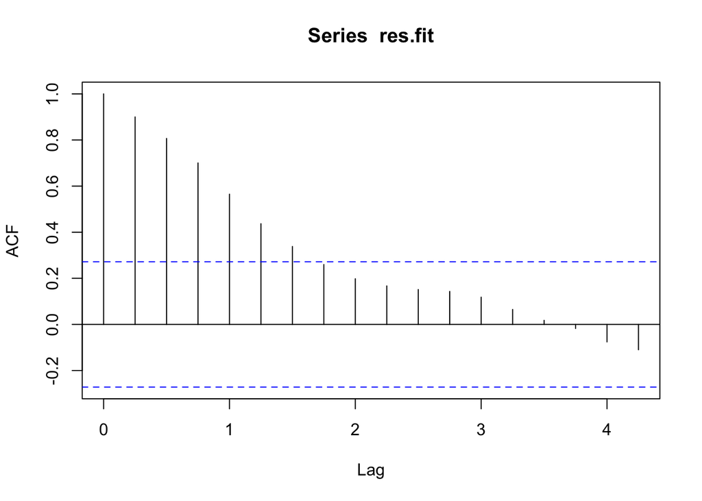

```r
res.fit<-ts(residuals(fit.reg),star=decimal_date(as.Date("2010-01-01",format = "%Y-%m-%d")),frequency = 4)
############## Then look at the residuals ############
acf(res.fit)
```

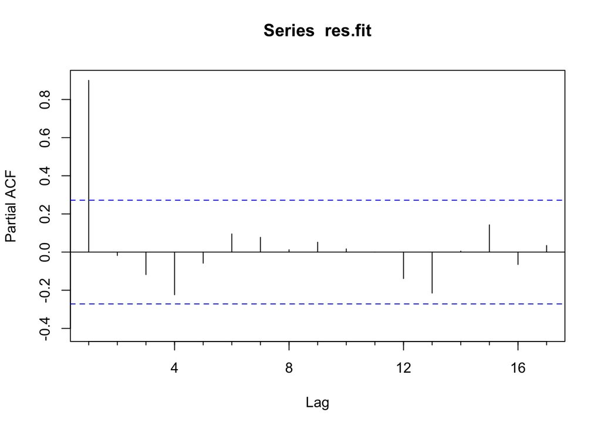

```r
Pacf(res.fit)
```

**Differentiated Residual**

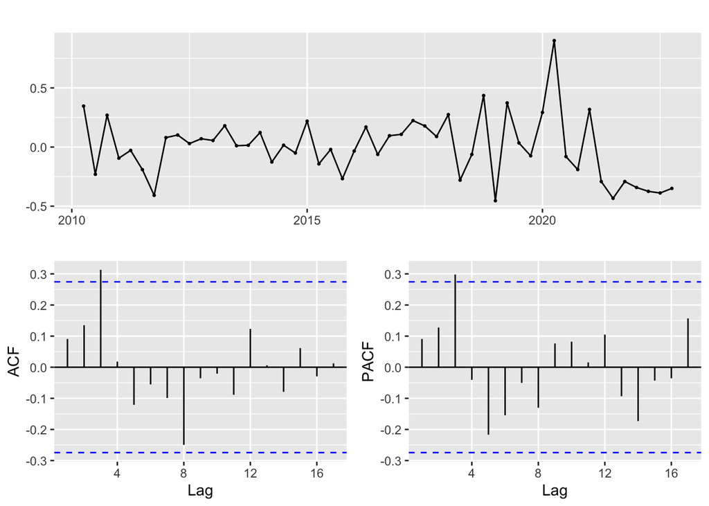

```r
res.fit %>% diff() %>% ggtsdisplay()
```

##### Finding the model parameters.

**ARIMAX Result**

```r
ARIMA.c=function(p1,p2,q1,q2,data){
temp=c()
d=1
i=1
temp= data.frame()
ls=matrix(rep(NA,6*30),nrow=30)


for (p in p1:p2)#
{
  for(q in q1:q2)#
  {
    for(d in 0:1)
    {

      if(p+d+q<=6)
      {

        model<- Arima(data,order=c(p,d,q))
        ls[i,]= c(p,d,q,model$aic,model$bic,model$aicc)
        i=i+1
        #print(i)

      }

    }
  }
}


temp= as.data.frame(ls)
names(temp)= c("p","d","q","AIC","BIC","AICc")

temp
}

output <- ARIMA.c(1,5,1,5,data=residuals(fit.reg))

output[which.min(output$AIC),]
```

```
  p d q      AIC      BIC     AICc
6 1 1 3 7.439979 17.09911 8.773313
```

```r
output[which.min(output$BIC),]
```

```
  p d q      AIC      BIC     AICc
6 1 1 3 7.439979 17.09911 8.773313
```

```r
output[which.min(output$AICc),]
```

```
  p d q      AIC      BIC     AICc
6 1 1 3 7.439979 17.09911 8.773313
```

**Model 1 Plot**

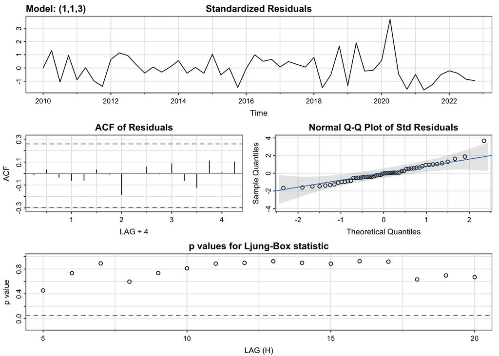

```r
set.seed(1234)

model_output_1 <- capture.output(sarima(res.fit, 1,1,3))
```

**Model 1**

```r
cat(model_output_1[45:78], model_output_1[length(model_output_1)], sep = "\n")
```

```
$fit

Call:
arima(x = xdata, order = c(p, d, q), seasonal = list(order = c(P, D, Q), period = S),
    xreg = constant, transform.pars = trans, fixed = fixed, optim.control = list(trace = trc,
        REPORT = 1, reltol = tol))

Coefficients:
         ar1      ma1     ma2     ma3  constant
      0.4565  -0.4496  0.1422  0.4319   -0.0068
s.e.  0.2077   0.2094  0.1524  0.1736    0.0654

sigma^2 estimated as 0.05442:  log likelihood = 1.29,  aic = 9.43

$degrees_of_freedom
[1] 46

$ttable
         Estimate     SE t.value p.value
ar1        0.4565 0.2077  2.1978  0.0330
ma1       -0.4496 0.2094 -2.1469  0.0371
ma2        0.1422 0.1524  0.9331  0.3557
ma3        0.4319 0.1736  2.4882  0.0165
constant  -0.0068 0.0654 -0.1040  0.9176

$AIC
[1] 0.1848859

$AICc
[1] 0.2110297

$BIC
[1] 0.4121595
```

**Model 2 Plot**

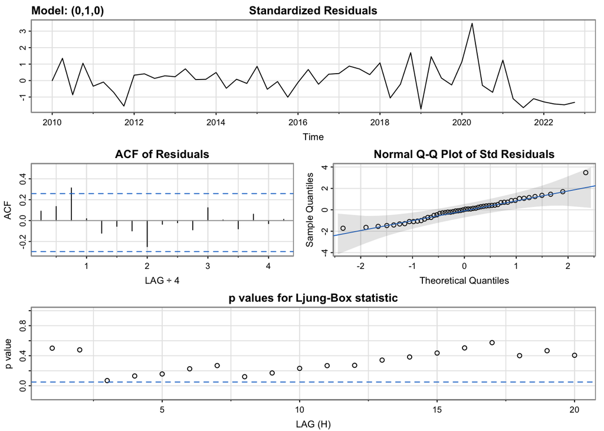

```r
model_output_2 <- capture.output(sarima(res.fit,0,1,0))
```

**Model 2**

```r
cat(model_output_2[9:38], model_output_2[length(model_output_2)], sep = "\n")
```

```
$fit

Call:
arima(x = xdata, order = c(p, d, q), seasonal = list(order = c(P, D, Q), period = S),
    xreg = constant, transform.pars = trans, fixed = fixed, optim.control = list(trace = trc,
        REPORT = 1, reltol = tol))

Coefficients:
      constant
       -0.0052
s.e.    0.0365

sigma^2 estimated as 0.06791:  log likelihood = -3.78,  aic = 11.56

$degrees_of_freedom
[1] 50

$ttable
         Estimate     SE t.value p.value
constant  -0.0052 0.0365 -0.1417  0.8879

$AIC
[1] 0.2267275

$AICc
[1] 0.2283282

$BIC
[1] 0.3024854
```

##### Cross Validation

**RMSE Plot**

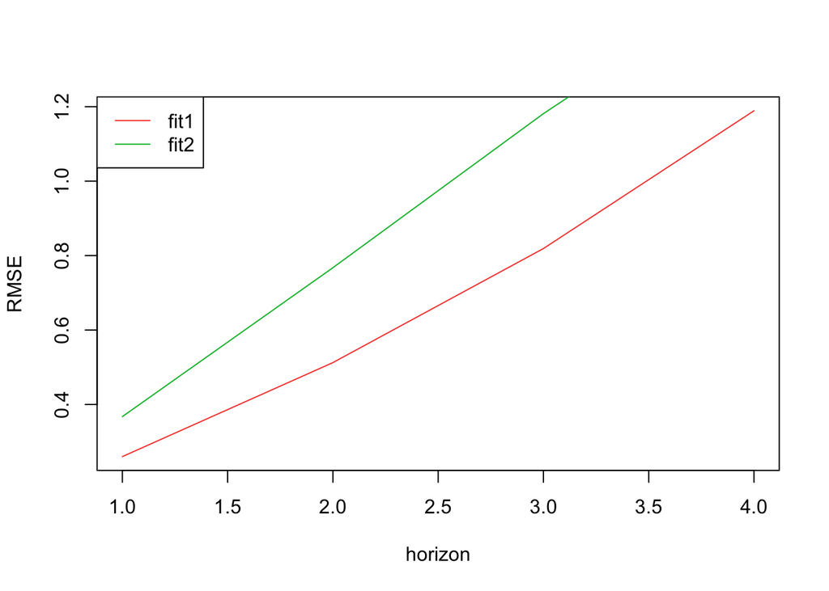

```r
n=length(res.fit)
k= 51


rmse1 <- matrix(NA, (n-k),4)
rmse2 <- matrix(NA, (n-k),4)


st <- tsp(res.fit)[1]+(k-5)/4

for(i in 1:(n-k))
{
  xtrain <- window(res.fit, end=st + i/4)
  xtest <- window(res.fit, start=st + (i+1)/4, end=st + (i+4)/4)

  #ARIMA(0,1,0) ARIMA(1,1,3)

  fit <- Arima(xtrain, order=c(1,1,3),
                include.drift=TRUE, method="ML")
  fcast <- forecast(fit, h=4)

  fit2 <- Arima(xtrain, order=c(0,1,0),
                include.drift=TRUE, method="ML")
  fcast2 <- forecast(fit2, h=4)



  rmse1[i,1:length(xtest)]   <- sqrt((fcast$mean-xtest)^2)
  rmse2[i,1:length(xtest)] <- sqrt((fcast2$mean-xtest)^2)

}

plot(1:4,colMeans(rmse1,na.rm=TRUE), type="l",col=2, xlab="horizon", ylab="RMSE")
lines(1:4, colMeans(rmse2,na.rm=TRUE), type="l",col=3)
legend("topleft",legend=c("fit1","fit2"),col=2:3,lty=1)
```

**RMSE Results**

```r
cat("RMSE values for Model 1\n", colMeans(rmse1))
```

```
RMSE values for Model 1
 0.2600182 0.512597 0.8190045 1.189145
```

```r
cat("RMSE values for Model 2\n", colMeans(rmse2))
```

```
RMSE values for Model 2
 0.3674812 0.7675162 1.181429 1.556654
```

The RMSE cross-validation plot shows that the RMSE of Model 1 (1,1,3) is lower than that of Model 2 (0,1,0). This suggests that Model 1 (1,1,3) is a better fit for the data when compared to Model 2 (0,1,0).

##### Forecast

**Forecast for DJI with feature variables**

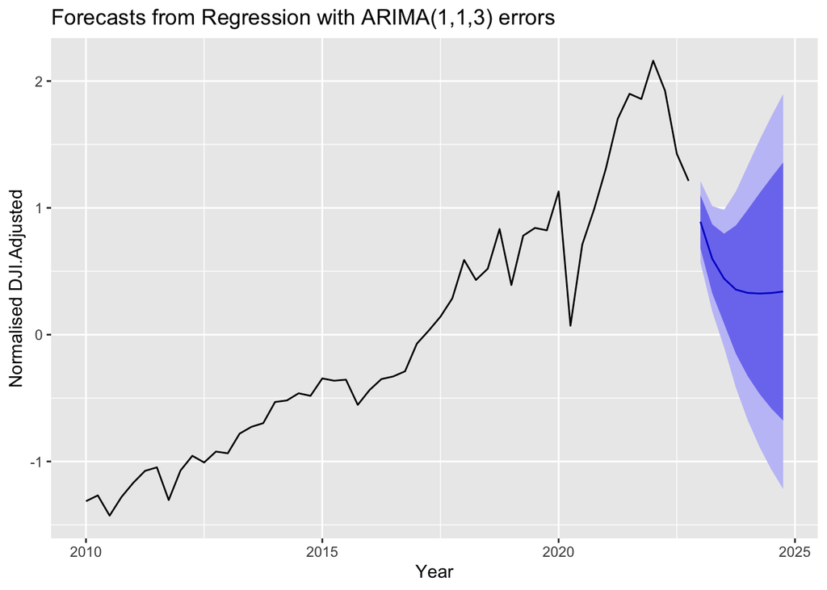

```r
#fiting an ARIMA model to the Inflation variable
inflation_fit<-auto.arima(normalized_dj_factor_data_numeric_df$inflation)
finflation<-forecast(inflation_fit)

#fitting an ARIMA model to the Unemployment variable
unemployment_fit<-auto.arima(normalized_dj_factor_data_numeric_df$unemployment)
funemployment<-forecast(unemployment_fit)

# best model fit for forcasting
xreg <- cbind(Inflation = normalized_dj_factor_data_ts[, "inflation"],
              Unemployment = normalized_dj_factor_data_ts[, "unemployment"])

fit <- Arima(normalized_dj_factor_data_ts[, "DJI.Adjusted"],order=c(1,1,3),xreg=xreg)

# Forcast the stock price using feature variables
fxreg <- cbind(Inflation = finflation$mean,
              Unemployment = funemployment$mean)
fcast <- forecast(fit, xreg=fxreg)
autoplot(fcast) + xlab("Year") +
  ylab("Normalised DJI.Adjusted")
```

**ARIMA Model for Inflation**

```r
#fiting an ARIMA model to the Inflation variable
inflation_fit<-auto.arima(normalized_dj_factor_data_numeric_df$inflation)
finflation<-forecast(inflation_fit)
summary(inflation_fit)
```

```
Series: normalized_dj_factor_data_numeric_df$inflation
ARIMA(0,1,3)(0,0,1)[4] with drift

Coefficients:
         ma1     ma2     ma3     sma1   drift
      0.2153  0.5354  0.4353  -0.3707  0.0567
s.e.  0.1719  0.1915  0.1455   0.1942  0.0499

sigma^2 = 0.0708:  log likelihood = -3.48
AIC=18.96   AICc=20.87   BIC=30.55

Training set error measures:
                      ME     RMSE       MAE       MPE    MAPE      MASE
Training set 0.002515126 0.250258 0.1802161 -17.11236 114.163 0.3180481
                    ACF1
Training set -0.06141191
```

**ARIMA Model for Employment**

```r
#fitting an ARIMA model to the Unemployment variable
unemployment_fit<-auto.arima(normalized_dj_factor_data_numeric_df$unemployment)
funemployment<-forecast(unemployment_fit)
summary(unemployment_fit)
```

```
Series: normalized_dj_factor_data_numeric_df$unemployment
ARIMA(0,1,2)

Coefficients:
          ma1      ma2
      -0.3027  -0.2410
s.e.   0.1376   0.1472

sigma^2 = 0.4982:  log likelihood = -53.72
AIC=113.45   AICc=113.96   BIC=119.24

Training set error measures:
                     ME      RMSE      MAE      MPE     MAPE      MASE
Training set -0.1001611 0.6851533 0.281119 140.1191 219.8632 0.4565275
                    ACF1
Training set -0.02079058
```

**ARIMA Model for DJI with feature variables**

```r
# best model fit for forcasting
xreg <- cbind(Inflation = normalized_dj_factor_data_ts[, "inflation"],
              Unemployment = normalized_dj_factor_data_ts[, "unemployment"])

fit <- Arima(normalized_dj_factor_data_ts[, "DJI.Adjusted"],order=c(1,1,3),xreg=xreg)
summary(fit)
```

```
Series: normalized_dj_factor_data_ts[, "DJI.Adjusted"]
Regression with ARIMA(1,1,3) errors

Coefficients:
         ar1      ma1     ma2     ma3  Inflation  Unemployment
      0.4207  -0.6167  0.3593  0.5494     0.2413       -0.2258
s.e.  0.2317   0.2680  0.2682  0.2372     0.0521        0.0188

sigma^2 = 0.02576:  log likelihood = 21.19
AIC=-28.38   AICc=-25.77   BIC=-14.85

Training set error measures:
                      ME      RMSE       MAE       MPE     MAPE      MASE
Training set 0.001852359 0.1492948 0.1197532 -2.903386 19.90147 0.3437973
                    ACF1
Training set -0.02545389
```